# Raspberries - Berries Project

10/19/2020

## Goal & Background

**Goal:** To compare the weight of raspberries in different states with different chemical applications.

- Data collected from USDA database
- Dataset has 3 berries (raspberries, strawberries, and blueberries), only concerned with raspberries

## Data Cleaning (part 1)

Remove NAs and single-outcome columns.

Year

Period

State

Commodity

Data Item

Domain

Domain Category

Value

2019

MARKETING YEAR

CALIFORNIA

BLUEBERRIES

BLUEBERRIES, TAME - PRICE RECEIVED, MEASURED IN $ / LB

TOTAL

NOT SPECIFIED

2.85

2019

MARKETING YEAR

CALIFORNIA

BLUEBERRIES

BLUEBERRIES, TAME, FRESH MARKET - PRICE RECEIVED, MEASURED IN $ / LB

TOTAL

NOT SPECIFIED

3.56

2019

MARKETING YEAR

CALIFORNIA

BLUEBERRIES

BLUEBERRIES, TAME, PROCESSING - PRICE RECEIVED, MEASURED IN $ / LB

TOTAL

NOT SPECIFIED

0.29

2019

MARKETING YEAR

CALIFORNIA

RASPBERRIES

RASPBERRIES - PRICE RECEIVED, MEASURED IN $ / LB

TOTAL

NOT SPECIFIED

2.69

2019

MARKETING YEAR

CALIFORNIA

RASPBERRIES

RASPBERRIES, FRESH MARKET - PRICE RECEIVED, MEASURED IN $ / LB

TOTAL

NOT SPECIFIED

2019

MARKETING YEAR

CALIFORNIA

RASPBERRIES

RASPBERRIES, PROCESSING - PRICE RECEIVED, MEASURED IN $ / LB

TOTAL

NOT SPECIFIED

## Data Cleaning (part 2)

Pull the raspberry data from the rest of the berries.

Determine and filter the Domain column to be only “TOTAL”.

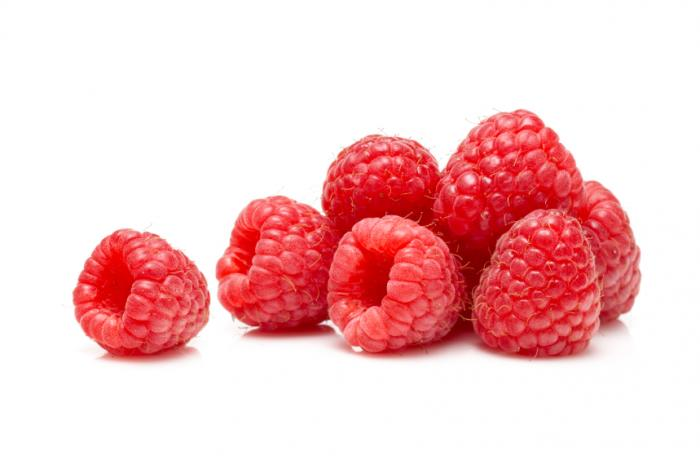

## Data Cleaning (part 3)

Clean even further by separating items in columns.

Year

State

Production

Measurement

Chemicals

Value

Chemical_Type

2019

CALIFORNIA

APPLICATIONS

MEASURED IN LB

(AZOXYSTROBIN = 128810)

FUNGICIDE

2019

CALIFORNIA

APPLICATIONS

MEASURED IN LB

(BACILLUS AMYLOLIQUEFACIENS STRAIN D747 = 16482)

(NA)

FUNGICIDE

2019

CALIFORNIA

APPLICATIONS

MEASURED IN LB

(BACILLUS SUBTILIS = 6479)

(NA)

FUNGICIDE

2019

CALIFORNIA

APPLICATIONS

MEASURED IN LB

(BORAX DECAHYDRATE = 11102)

FUNGICIDE

2019

CALIFORNIA

APPLICATIONS

MEASURED IN LB

(BOSCALID = 128008)

300

FUNGICIDE

2019

CALIFORNIA

APPLICATIONS

MEASURED IN LB

(CALCIUM POLYSULFIDE = 76702)

FUNGICIDE

## Exploratory Data Analysis (EDA) - Histogram 1

**Goal:** Look for patterns in the visualized data.

- Not much data in 2016 or 2018

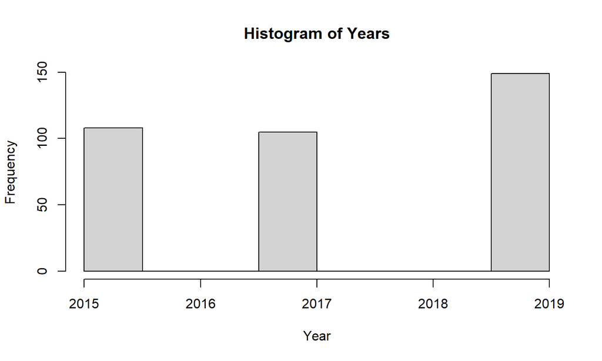

## EDA - Histogram 2

- Heavily right-skewed

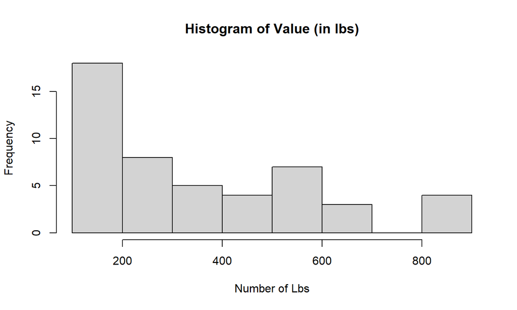

## EDA - Scatterplot

- Different colors represent different states

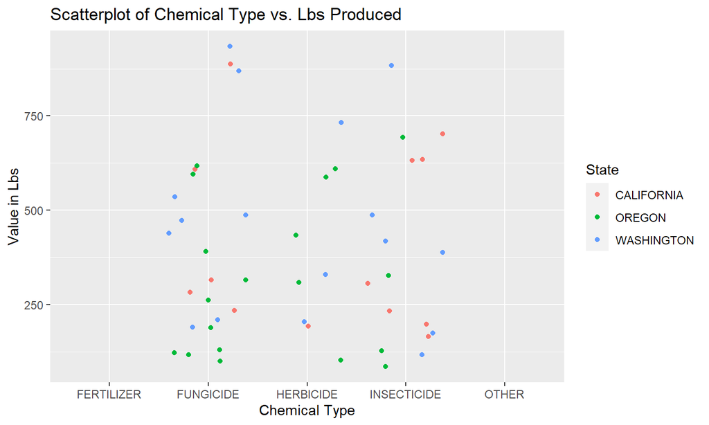

## EDA - Calculations

| State | mean(Value, na.rm = TRUE) |
| --- | --- |
| CALIFORNIA | 407.6923 |
| OREGON | 315.7895 |
| WASHINGTON | 458.8235 |

| Year | mean(Value, na.rm = TRUE) |
| --- | --- |
| 2015 | 406.6667 |
| 2017 | 388.8889 |
| 2019 | 375.0000 |

| Chemical_Type | mean(Value, na.rm = TRUE) |
| --- | --- |
| FERTILIZER | NaN |
| FUNGICIDE | 400.0000 |
| HERBICIDE | 377.7778 |
| INSECTICIDE | 382.3529 |
| OTHER | NaN |

## Conclusion

**Goal:** To compare the weight of raspberries in different states with different chemical applications.

- Histograms
  - most raspberries were between 0 and 600 lbs
- Scatterplot
  - WA tends to have heavier raspberries than CA and OR
  - not many farms use herbicides (CA barely uses it at all)
- Tables
  - on average, WA has heavier raspberries
  - on average, OR has the lighest raspberries

## References

1. Bruce Cowles, Anna Cook. Personalized advice in meetings.
2. Hadley Wickham, Romain François, Lionel Henry and Kirill Müller (2020). dplyr: A Grammar of Data Manipulation. R package version 1.0.2. https://CRAN.R-project.org/package=dplyr
3. Hao Zhu (2020). kableExtra: Construct Complex Table with ‘kable’ and Pipe Syntax. R package version 1.2.1. https://CRAN.R-project.org/package=kableExtra
4. H. Wickham. ggplot2: Elegant Graphics for Data Analysis. Springer-Verlag New York, 2016.
5. Stefan Milton Bache and Hadley Wickham (2014). magrittr: A Forward-Pipe Operator for R. R package version 1.5. https://CRAN.R-project.org/package=magrittr
6. Wickham et al., (2019). Welcome to the tidyverse. Journal of Open Source Software, 4(43), 1686, https://doi.org/10.21105/joss.01686
7. Yihui Xie (2020). knitr: A General-Purpose Package for Dynamic Report Generation in R. R package version 1.29.